# Analysis and prediction on Heart Attack

## Overview

#### What are some facts about the heart attack? What even is heart attack?

"A heart attack, also called a myocardial infarction, happens when a part of the heart muscle doesn’t get enough blood."[link](https://www.cdc.gov/heartdisease/heart_attack.htm) The longer the effect lasts, the more damage is done to the heart, and eventually causing searious problem to the person being affected.

According to [CDC data](https://www.cdc.gov/heartdisease/facts.htm), "Heart disease is the leading cause of death for men, women, and people of most racial and ethnic groups in the United States."

One in every five deaths were caused by heart disease in the United States in 2020.

About one in five heart attacks were "silent": the patient would not notice the heart attack from happening. There is still damage being dealt.

#### Why would I choose this dataset and this topic to predict?

In the 5 minutes that you might be spending reading the above linked information, there are about 8 to 9 people died of cardiovascular disease and about 7 to 8 people having a heart attack, just in the United States. It would be benefical to figure out what would be the characterstics of a heart attack, and thus predicting it and then maybe being able to prevent it. The earlier we are being able to spot the potiental heart disease from the other data or symptoms, the more likely that we could save lives early on.

## First, let's import the data and set things up.

```python
#This area is for Importing necessary features.
import pandas as pd
import numpy as np
import matplotlib.pyplot as plt
import seaborn as sns
from sklearn.experimental import enable_iterative_imputer
from sklearn.impute import IterativeImputer
import warnings
warnings.simplefilter(action='ignore', category=FutureWarning)
import lazypredict
import sklearn
from lazypredict.Supervised import LazyClassifier
from sklearn.model_selection import train_test_split
from sklearn.preprocessing import StandardScaler
from sklearn.discriminant_analysis import LinearDiscriminantAnalysis as LDA
from sklearn.metrics import confusion_matrix
from sklearn.metrics import accuracy_score
from sklearn.metrics import precision_recall_fscore_support
from sklearn.model_selection import GridSearchCV
from sklearn.ensemble import RandomForestClassifier
from sklearn.neighbors import KNeighborsClassifier
from sklearn.svm import LinearSVC
from sklearn.pipeline import make_pipeline
from sklearn.datasets import make_classification
from sklearn.inspection import permutation_importance
from sklearn import svm
```

Information from the dataset's provider: (this data is provided by Rashik Rahman on kaggle, link is [here](https://www.kaggle.com/datasets/rashikrahmanpritom/heart-attack-analysis-prediction-dataset?select=heart.csv))

### About this dataset

#### Age : Age of the patient

#### Sex : Sex of the patient

#### cp : Chest Pain type

Value 0: asymptomatic

Value 1: typical angina

Value 2: atypical angina

Value 3: non-anginal pain

#### trtbps : resting blood pressure (in mm Hg)

#### chol : Cholesterol in mg/dl fetched via BMI sensor [What is cholesterol?](https://www.cdc.gov/cholesterol/index.htm)

#### fbs : (fasting blood sugar > 120 mg/dl)

Value 0: false

Value 1: true

#### restecg : resting electrocardiographic results

Value 0: normal

Value 1: having ST-T wave abnormality (T wave inversions and/or ST elevation or depression of > 0.05 mV)

Value 2: showing probable or definite left ventricular hypertrophy by Estes' criteria

#### thalach : maximum heart rate achieved

#### exng : exercise induced angina [What is angina?](https://www.cdc.gov/heartdisease/other_conditions.htm)

Value 0: false

Value 1: true

#### old peak : ST depression induced by exercise relative to rest [What is ST depression?](https://www.ncbi.nlm.nih.gov/books/NBK459364/)

#### slp : the slope of the peak exercise ST segment

Value 0: downsloping

Value 1: flat

Value 2: upsloping

#### caa : number of major vessels (0-3) [What are the major vessels?](https://www.cdc.gov/ncbddd/heartdefects/howtheheartworks.html)

#### thall : [Thallium Stress Test](https://www.healthline.com/health/thallium-stress-test)

Value 1: fixed defect

Value 2: normal

Value 3: reversible defect

#### output : Whether the person have a high chance of heart attack or not

Value 0: less chance of heart attack

Value 1: more chance of heart attack

Since we already have the csv file, currently there is no need to pull data from websites. However, you might also notice that on the original kaggle page, there is another file that contains the data of O2 Saturation, however that data would be having 3,500 rows and this data only have 303 rows, and they can't match up quite well. Therefore, I have to ignore that data.

```python
df = pd.read_csv('heart.csv')
print("The number of data(or rows) we have are:", len(df))
df.head()
```

```
The number of data(or rows) we have are: 303
```

|  | age | sex | cp | trtbps | chol | fbs | restecg | thalachh | exng | oldpeak | slp | caa | thall | output |
| --- | --- | --- | --- | --- | --- | --- | --- | --- | --- | --- | --- | --- | --- | --- |
| 0 | 63 | 1 | 3 | 145 | 233 | 1 | 0 | 150 | 0 | 2.30 | 0 | 0 | 1 | 1 |
| 1 | 37 | 1 | 2 | 130 | 250 | 0 | 1 | 187 | 0 | 3.50 | 0 | 0 | 2 | 1 |
| 2 | 41 | 0 | 1 | 130 | 204 | 0 | 0 | 172 | 0 | 1.40 | 2 | 0 | 2 | 1 |
| 3 | 56 | 1 | 1 | 120 | 236 | 0 | 1 | 178 | 0 | 0.80 | 2 | 0 | 2 | 1 |
| 4 | 57 | 0 | 0 | 120 | 354 | 0 | 1 | 163 | 1 | 0.60 | 2 | 0 | 2 | 1 |

Now, time to check if the data have any missing values, or values that are not realistic. For example, age, trtbps(resting blood pressure), chol(cholesterol) and thalach(maximum heart rate) were all not possible to be zero. If they are zero, then we would have to treat them as missing value.

```python
print("The number of \"missing\" data we have are:\n", df.isnull().sum())
```

```
The number of "missing" data we have are:
 age         0
sex         0
cp          0
trtbps      0
chol        0
fbs         0
restecg     0
thalachh    0
exng        0
oldpeak     0
slp         0
caa         0
thall       0
output      0
dtype: int64
```

We don't have any missing data(in the rough check), that is great. Now, time to check if we have any data that are not realistic.

```python
print("The number of missing age value are:",(df['age'] <= 0).sum())
print("The number of missing resting blood pressure value are:",(df['trtbps'] <= 0).sum())
print("The number of missing cholesterol value are:",(df['chol'] <= 0).sum())
print("The number of missing maximum heart rate value are:",(df['thalachh'] <= 0).sum())
```

```
The number of missing age value are: 0
The number of missing resting blood pressure value are: 0
The number of missing cholesterol value are: 0
The number of missing maximum heart rate value are: 0
```

Great, it seems like that we also do not have any missing values on these four columns. However, there is one(actually two) more things that need to be checked. In the [description](https://www.kaggle.com/datasets/rashikrahmanpritom/heart-attack-analysis-prediction-dataset/discussion/234843?select=heart.csv) provided by the author of the dataset, the caa(number of major vessels) value should be between 0 to 3, and the thall value should be between 1 to 3. Any numbers other than that should be considered not realistic values.

```python
df['caa'].unique()
```

```
array([0, 2, 1, 3, 4], dtype=int64)
```

```python
print("The number of missing number of major vessels value are:",(df['caa'] == 4).sum())
```

```
The number of missing number of major vessels value are: 5
```

```python
df['thall'].unique()
```

```
array([1, 2, 3, 0], dtype=int64)
```

```python
print("The number of missing thall value are:",(df['thall'] == 0).sum())
```

```
The number of missing thall value are: 2
```

It seems that there are some missing values here. However, these missing data rows are just consists of less than 3% of the data, and I would drop them first for easier statistical analysis. We would come back to them later.

```python
#First, find the rows that have error
df.loc[(df['caa'] == 4) | (df['thall'] == 0)].index
```

```
Int64Index([48, 92, 158, 163, 164, 251, 281], dtype='int64')
```

```python
#This gives us the missing rows, which are 48, 92, 158, 163, 164, 251, 281.
missing_rows = [48, 92, 158, 163, 164, 251, 281]
df_remove_missing = df.drop(missing_rows, axis=0)
df_remove_missing
```

|  | age | sex | cp | trtbps | chol | fbs | restecg | thalachh | exng | oldpeak | slp | caa | thall | output |
| --- | --- | --- | --- | --- | --- | --- | --- | --- | --- | --- | --- | --- | --- | --- |
| 0 | 63 | 1 | 3 | 145 | 233 | 1 | 0 | 150 | 0 | 2.30 | 0 | 0 | 1 | 1 |
| 1 | 37 | 1 | 2 | 130 | 250 | 0 | 1 | 187 | 0 | 3.50 | 0 | 0 | 2 | 1 |
| 2 | 41 | 0 | 1 | 130 | 204 | 0 | 0 | 172 | 0 | 1.40 | 2 | 0 | 2 | 1 |
| 3 | 56 | 1 | 1 | 120 | 236 | 0 | 1 | 178 | 0 | 0.80 | 2 | 0 | 2 | 1 |
| 4 | 57 | 0 | 0 | 120 | 354 | 0 | 1 | 163 | 1 | 0.60 | 2 | 0 | 2 | 1 |
| ... | ... | ... | ... | ... | ... | ... | ... | ... | ... | ... | ... | ... | ... | ... |
| 298 | 57 | 0 | 0 | 140 | 241 | 0 | 1 | 123 | 1 | 0.20 | 1 | 0 | 3 | 0 |
| 299 | 45 | 1 | 3 | 110 | 264 | 0 | 1 | 132 | 0 | 1.20 | 1 | 0 | 3 | 0 |
| 300 | 68 | 1 | 0 | 144 | 193 | 1 | 1 | 141 | 0 | 3.40 | 1 | 2 | 3 | 0 |
| 301 | 57 | 1 | 0 | 130 | 131 | 0 | 1 | 115 | 1 | 1.20 | 1 | 1 | 3 | 0 |
| 302 | 57 | 0 | 1 | 130 | 236 | 0 | 0 | 174 | 0 | 0.00 | 1 | 1 | 2 | 0 |

296 rows × 14 columns

And here we have the data set that is being pre_processed. What could also be done in this case would be using [scikit learn](https://scikit-learn.org/stable/modules/impute.html) to fit in the missing values, which I would be demonstrate below.

I have chosen to use the feature called "[Multivariate feature imputation(more info can be seen here)](https://towardsdatascience.com/a-better-way-to-handle-missing-values-in-your-dataset-using-iterativeimputer-9e6e84857d98#8303)", which is basically building up a function based on other not missing values that was contained in the dataset, then use that function to estimate the missing value in the dataset. That is being said, it is similar to (missing value) = a*(not missing value 1) + b*(not missing value 2) + c*(not missing value 3)...

Basically, it is very useful when you have a lot of features, and a few of them were just missing. In this case(of my data), there are a lot of features(13 features in total), and on 303 rows only 7 rows have 1 missing value, which would be very effective to use this method. However, we would want to first replace the "wrong" values with np.nan, then we can do the processing.

```python
df_replace_missing = df.copy() #copy a dataframe for changing data
#Replacing the values with nan
df_replace_missing['caa'].replace(4, np.NaN, inplace = True)
df_replace_missing['thall'].replace(0, np.NaN, inplace = True)
#checking the result
df_replace_missing.loc[(df_replace_missing['caa'] == 4) | (df_replace_missing['thall'] == 0)].index
```

```
Int64Index([], dtype='int64')
```

Then, we can tell the sklearn to figure out what would be the best fitting model for the missing values.

```python
imp = IterativeImputer(max_iter=100, random_state=0)
imp.fit(df_replace_missing)
```

```
IterativeImputer(max_iter=100, random_state=0)
```

With the model in our hand, we can first create a smaller dataset with the missing values to see if they are being changed correctly.

```python
missings = df.copy().loc[(df['caa'] == 4) | (df['thall'] == 0)]
missings['caa'].replace(4, np.NaN, inplace = True)
missings['thall'].replace(0, np.NaN, inplace = True)

print(np.round(imp.transform(missings)))
#Looks like it's working. Let's put the values into the actual datasets.
```

```
[[ 53.   0.   2. 128. 216.   0.   0. 115.   0.   0.   2.   0.   2.   1.]
 [ 52.   1.   2. 138. 223.   0.   1. 169.   0.   0.   2.   0.   2.   1.]
 [ 58.   1.   1. 125. 220.   0.   1. 144.   0.   0.   1.   0.   3.   1.]
 [ 38.   1.   2. 138. 175.   0.   1. 173.   0.   0.   2.  -0.   2.   1.]
 [ 38.   1.   2. 138. 175.   0.   1. 173.   0.   0.   2.  -0.   2.   1.]
 [ 43.   1.   0. 132. 247.   1.   0. 143.   1.   0.   1.   1.   3.   0.]
 [ 52.   1.   0. 128. 204.   1.   1. 156.   1.   1.   1.   0.   2.   0.]]
```

Then, we can put the model into actual use and change the copied dataset.

```python
df_replace_missing = pd.DataFrame(imp.transform(df_replace_missing), columns = df.columns) #change the result(which is an array) into datasets.
df_replace_missing["caa"] = np.round(df_replace_missing["caa"])
df_replace_missing["thall"] = np.round(df_replace_missing["thall"])
#I have to round up because the other values are all round up, and they are basically categorical data.
print(df_replace_missing["caa"].unique())
print(df_replace_missing["thall"].unique())
#I should be seeing only integers with range 0 to 3 and 1 to 3. It does convert the whole number to float, but they are still rounded up.
df_replace_missing
```

```
[0. 2. 1. 3.]
[1. 2. 3.]
```

|  | age | sex | cp | trtbps | chol | fbs | restecg | thalachh | exng | oldpeak | slp | caa | thall | output |
| --- | --- | --- | --- | --- | --- | --- | --- | --- | --- | --- | --- | --- | --- | --- |
| 0 | 63.00 | 1.00 | 3.00 | 145.00 | 233.00 | 1.00 | 0.00 | 150.00 | 0.00 | 2.30 | 0.00 | 0.00 | 1.00 | 1.00 |
| 1 | 37.00 | 1.00 | 2.00 | 130.00 | 250.00 | 0.00 | 1.00 | 187.00 | 0.00 | 3.50 | 0.00 | 0.00 | 2.00 | 1.00 |
| 2 | 41.00 | 0.00 | 1.00 | 130.00 | 204.00 | 0.00 | 0.00 | 172.00 | 0.00 | 1.40 | 2.00 | 0.00 | 2.00 | 1.00 |
| 3 | 56.00 | 1.00 | 1.00 | 120.00 | 236.00 | 0.00 | 1.00 | 178.00 | 0.00 | 0.80 | 2.00 | 0.00 | 2.00 | 1.00 |
| 4 | 57.00 | 0.00 | 0.00 | 120.00 | 354.00 | 0.00 | 1.00 | 163.00 | 1.00 | 0.60 | 2.00 | 0.00 | 2.00 | 1.00 |
| ... | ... | ... | ... | ... | ... | ... | ... | ... | ... | ... | ... | ... | ... | ... |
| 298 | 57.00 | 0.00 | 0.00 | 140.00 | 241.00 | 0.00 | 1.00 | 123.00 | 1.00 | 0.20 | 1.00 | 0.00 | 3.00 | 0.00 |
| 299 | 45.00 | 1.00 | 3.00 | 110.00 | 264.00 | 0.00 | 1.00 | 132.00 | 0.00 | 1.20 | 1.00 | 0.00 | 3.00 | 0.00 |
| 300 | 68.00 | 1.00 | 0.00 | 144.00 | 193.00 | 1.00 | 1.00 | 141.00 | 0.00 | 3.40 | 1.00 | 2.00 | 3.00 | 0.00 |
| 301 | 57.00 | 1.00 | 0.00 | 130.00 | 131.00 | 0.00 | 1.00 | 115.00 | 1.00 | 1.20 | 1.00 | 1.00 | 3.00 | 0.00 |
| 302 | 57.00 | 0.00 | 1.00 | 130.00 | 236.00 | 0.00 | 0.00 | 174.00 | 0.00 | 0.00 | 1.00 | 1.00 | 2.00 | 0.00 |

303 rows × 14 columns

And now I think we would be having clean data from now on. I have decided to use the df_replace_missing data, the one that I have replaced missing data with predicted value, since there are a bit more data.

## Then, it's time to do some statistical analysis

The first thing we might want to know would be the distribution of the output. An unbalanced output could lead to the training set just giving out one answer, which would also have a very high accuracy in the test set and training set. If our training set has this problem, we might want to do some more work. Giving out one answer only might be working for the training dataset, however it could be more challenging for a real world situation.

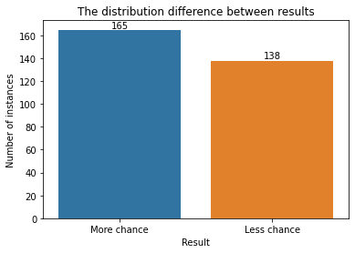

```python
#We shall begin with plotting a countplot of the output column, which contains the result of the training dataset.
#We hope that they would be as close to 50 - 50 as possible.
results = {0: 'Less chance', 1: 'More chance'}
output_distribution_fig = sns.countplot(df_replace_missing['output'].map(results))
output_distribution_fig.set(xlabel='Result', ylabel='Number of instances', title='The distribution difference between results')
output_distribution_fig.bar_label(output_distribution_fig.containers[0])
plt.show()
```

As you can see here, the distribution is quite close to 50 - 50, which would be good. What about other distributions of the data? This would be a bit messy, since the categorical datas are mix into the dataset. Therefore, we would want to plot them seperately.

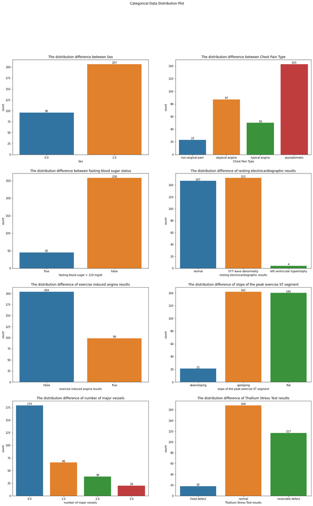

```python
df_replace_missing_c = df_replace_missing[['sex', 'cp', 'fbs', 'restecg', 'exng', 'slp', 'caa', 'thall', 'output']]
cp_read = {0: 'asymptomatic', 1: 'typical angina', 2: 'atypical angina', 3: 'non-anginal pain'}
fbs_read = {0: 'False', 1: 'True'}
restecg_read = {0: 'normal', 1: 'ST-T wave abnormality', 2: 'left ventricular hypertrophy'}
exng_read = {0: 'False', 1: 'True'}
slp_read = {0: 'downsloping', 1: 'flat', 2: 'upsloping'}
thall_read = {1: 'fixed defect', 2: 'normal', 3: 'reversible defect'}

#plotting and labeling
#It is possible to use loops here, but I found that it would be more messy to set their individual plot name and their label names
#using a loop, therefore I choose to do that one by one here.
fig, ax =plt.subplots(4,2, figsize=(20, 30))
p0 = sns.countplot(df_replace_missing_c['sex'], ax=ax[(0,0)])
p0.set(xlabel='Sex', title='The distribution difference between Sex')

p1 = sns.countplot(df_replace_missing_c['cp'].map(cp_read), ax=ax[(0,1)])
p1.set(xlabel='Chest Pain Type', title='The distribution difference between Chest Pain Type')

p2 = sns.countplot(df_replace_missing_c['fbs'].map(fbs_read), ax=ax[(1,0)])
p2.set(xlabel='fasting blood sugar > 120 mg/dl', title='The distribution difference between fasting blood sugar status')

p3 = sns.countplot(df_replace_missing_c['restecg'].map(restecg_read), ax=ax[(1,1)])
p3.set(xlabel='resting electrocardiographic results', title='The distribution difference of resting electrocardiographic results')

p4 = sns.countplot(df_replace_missing_c['exng'].map(exng_read), ax=ax[(2,0)])
p4.set(xlabel='exercise induced angina results', title='The distribution difference of exercise induced angina results')

p5 = sns.countplot(df_replace_missing_c['slp'].map(slp_read), ax=ax[(2,1)])
p5.set(xlabel='slope of the peak exercise ST segment', title='The distribution difference of slope of the peak exercise ST segment')

p6 = sns.countplot(df_replace_missing_c['caa'], ax=ax[(3,0)])
p6.set(xlabel='number of major vessels', title='The distribution difference of number of major vessels')

p7 = sns.countplot(df_replace_missing_c['thall'].map(thall_read), ax=ax[(3,1)])
p7.set(xlabel='Thallium Stress Test results', title='The distribution difference of Thallium Stress Test results')

fig.suptitle('Categorical Data Distribution Plot')
plt_list = [p0, p1, p2, p3, p4, p5, p6, p7]
for p in plt_list:
    p.bar_label(p.containers[0])
plt.show()
```

We can make a few observations on these results. For example, on the chest pain type, about a half of the observations we make here are asymptomatic, which is quite similar to the number of observations that are less likely to have a heart attack. Are they somehow related? We can also do a plot to find this out.

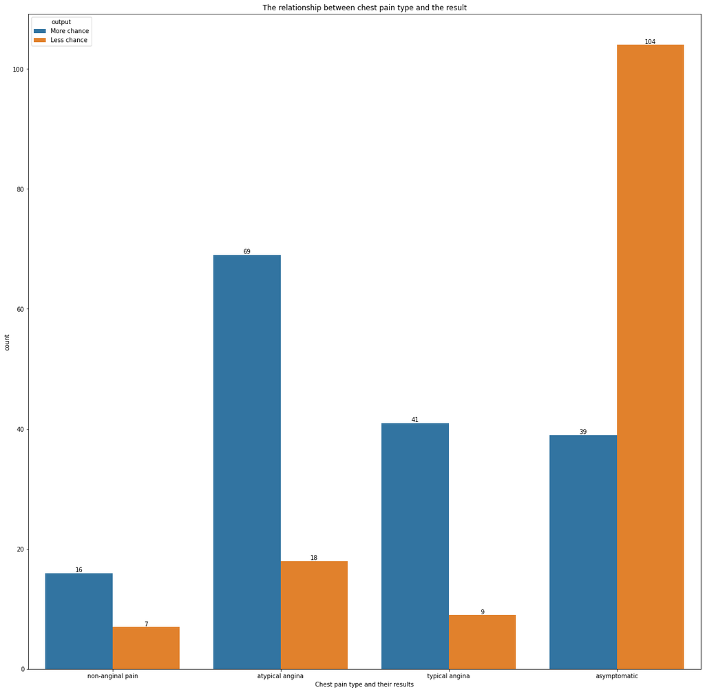

```python
df_cp_output = df_replace_missing[['cp', 'output']] #Isolate out the desired data
fig, ax =plt.subplots(1,1, figsize=(20, 20))
p0 = sns.countplot(x = (df_cp_output['cp'].map(cp_read)), hue = df_cp_output['output'].map(results))
p0.set(xlabel='Chest pain type and their results', title='The relationship between chest pain type and the result')
for container in ax.containers:
    ax.bar_label(container)
```

From this plot, it does seem like that if the observation is asymptomatic, then the person is less likely to have a heart attack. This also matches with the expection of about 1 out of 5 heart attacks were "silent".(Over here, about one in four person that have a high chance of heart attack are asymptomatic). Then, we might want to do some violin plots on the numerical datas that are in the dataset and see their distributions.

According to [CDC data](https://www.cdc.gov/bloodpressure/about.htm), I have plot the lines of normal blood pressure and cholesterol level. For blood pressure, if the value is above the blue line, then the patient have a problem of high blood pressure, and if it is above 140, then the patient have a serious high blood pressure problem. For the cholesterol level, if the person's value is around the blue line, then they are fine. If the value is above the red line, they have a high cholesterol problem.

[output not shown]

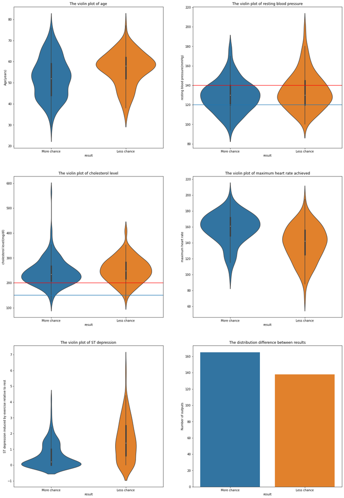

```python
df_replace_missing_n = df_replace_missing[['age', 'trtbps', 'chol', 'thalachh', 'oldpeak', 'output']].copy()
df_replace_missing_n['output'] = df_replace_missing_n['output'].map(results)
fig, ax =plt.subplots(3,2, figsize=(20, 30))
p0 = sns.violinplot(data = df_replace_missing_n, x = 'output', y = 'age', ax=ax[(0,0)])
p0.set(xlabel='result', ylabel = 'Age(years)', title='The violin plot of age')

p1 = sns.violinplot(data = df_replace_missing_n, x = 'output', y = 'trtbps', ax=ax[(0,1)])
p1.set(xlabel='result', ylabel='resting blood pressure(mmHg)', title='The violin plot of resting blood pressure')
p1.axhline(y = 120, xmin = 0, xmax = 1) #Below this line is normal blood pressure
p1.axhline(y = 140, xmin = 0, xmax = 1, color = 'r') #Above this line is very serious high blood pressure

p2 = sns.violinplot(data = df_replace_missing_n, x = 'output', y = 'chol', ax=ax[(1,0)])
p2.set(xlabel='result', ylabel='cholesterol level(mg/dl)', title='The violin plot of cholesterol level')
p2.axhline(y = 150, xmin = 0, xmax = 1) #Around this line is normal cholesterol level
p2.axhline(y = 200, xmin = 0, xmax = 1, color = 'r') #Above this line is high cholesterol level

#It is possible to plot the optimal heart rate lines, but I found it is very confusing and there are too many possible lines to plot here
#making it less possible to understand.
p3 = sns.violinplot(data = df_replace_missing_n, x = 'output', y = 'thalachh', ax=ax[(1,1)])
p3.set(xlabel='result', ylabel='maximum heart rate', title='The violin plot of maximum heart rate achieved')

#Some resources suggested below 0.5, some suggested below 0.05. Since I don't want to introduce my own bias into this, I prefer to not
#draw the lines.
p4 = sns.violinplot(data = df_replace_missing_n, x = 'output', y = 'oldpeak', ax=ax[(2,0)])
p4.set(xlabel='result', ylabel='ST depression induced by exercise relative to rest', title='The violin plot of ST depression')

#fill the last empty plot with the output plot
p5 = sns.countplot(df_replace_missing_n['output'], ax=ax[(2,1)])
p5.set(xlabel='result', ylabel='Number of outputs', title='The distribution difference between results')
```

As you can see here, in these plots we can make some more observations. For example, almost all of the person in this dataset have above normal blood pressure and above normal cholesteol level. It also seems like that the people with more chance to have a heart attack have a higher heart rate. The distribution of age is also a bit concerning to me, as it shows that the average age of people with less chance of heart attack are older than the average age of people that have higher chance of heart attack, and they are all concerntrated in the age 60 range. This could be a bit of a problem in our maching learning and classifing algorithm later. If we want to predict a real-world senario more effectively, we might want to have a dataset that is more evenly spread in this case.

After seeing the plot of the categorical and numerical distributions, we now can try to find their correlations with the output data. That is, finding the most related features between the input information and the results.

```python
df_replace_missing.corr()
```

|  | age | sex | cp | trtbps | chol | fbs | restecg | thalachh | exng | oldpeak | slp | caa | thall | output |
| --- | --- | --- | --- | --- | --- | --- | --- | --- | --- | --- | --- | --- | --- | --- |
| age | 1.00 | -0.10 | -0.07 | 0.28 | 0.21 | 0.12 | -0.12 | -0.40 | 0.10 | 0.21 | -0.17 | 0.37 | 0.07 | -0.23 |
| sex | -0.10 | 1.00 | -0.05 | -0.06 | -0.20 | 0.05 | -0.06 | -0.04 | 0.14 | 0.10 | -0.03 | 0.08 | 0.21 | -0.28 |
| cp | -0.07 | -0.05 | 1.00 | 0.05 | -0.08 | 0.09 | 0.04 | 0.30 | -0.39 | -0.15 | 0.12 | -0.23 | -0.17 | 0.43 |
| trtbps | 0.28 | -0.06 | 0.05 | 1.00 | 0.12 | 0.18 | -0.11 | -0.05 | 0.07 | 0.19 | -0.12 | 0.10 | 0.06 | -0.14 |
| chol | 0.21 | -0.20 | -0.08 | 0.12 | 1.00 | 0.01 | -0.15 | -0.01 | 0.07 | 0.05 | -0.00 | 0.13 | 0.09 | -0.09 |
| fbs | 0.12 | 0.05 | 0.09 | 0.18 | 0.01 | 1.00 | -0.08 | -0.01 | 0.03 | 0.01 | -0.06 | 0.15 | -0.01 | -0.03 |
| restecg | -0.12 | -0.06 | 0.04 | -0.11 | -0.15 | -0.08 | 1.00 | 0.04 | -0.07 | -0.06 | 0.09 | -0.12 | -0.01 | 0.14 |
| thalachh | -0.40 | -0.04 | 0.30 | -0.05 | -0.01 | -0.01 | 0.04 | 1.00 | -0.38 | -0.34 | 0.39 | -0.27 | -0.12 | 0.42 |
| exng | 0.10 | 0.14 | -0.39 | 0.07 | 0.07 | 0.03 | -0.07 | -0.38 | 1.00 | 0.29 | -0.26 | 0.15 | 0.23 | -0.44 |
| oldpeak | 0.21 | 0.10 | -0.15 | 0.19 | 0.05 | 0.01 | -0.06 | -0.34 | 0.29 | 1.00 | -0.58 | 0.30 | 0.21 | -0.43 |
| slp | -0.17 | -0.03 | 0.12 | -0.12 | -0.00 | -0.06 | 0.09 | 0.39 | -0.26 | -0.58 | 1.00 | -0.11 | -0.11 | 0.35 |
| caa | 0.37 | 0.08 | -0.23 | 0.10 | 0.13 | 0.15 | -0.12 | -0.27 | 0.15 | 0.30 | -0.11 | 1.00 | 0.15 | -0.47 |
| thall | 0.07 | 0.21 | -0.17 | 0.06 | 0.09 | -0.01 | -0.01 | -0.12 | 0.23 | 0.21 | -0.11 | 0.15 | 1.00 | -0.36 |
| output | -0.23 | -0.28 | 0.43 | -0.14 | -0.09 | -0.03 | 0.14 | 0.42 | -0.44 | -0.43 | 0.35 | -0.47 | -0.36 | 1.00 |

This is a bit hard to read, but we can now also try to plot a heatmap of the correlations of the data. More informations can be found [here](https://medium.com/@szabo.bibor/how-to-create-a-seaborn-correlation-heatmap-in-python-834c0686b88e)

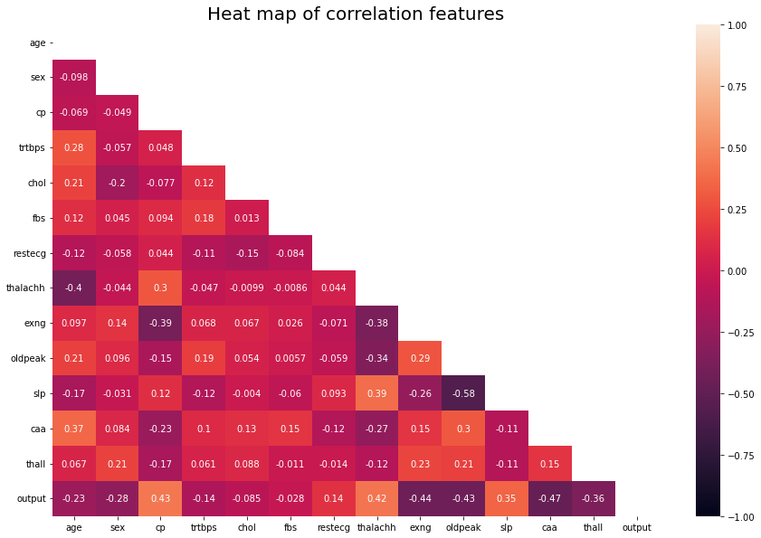

```python
plt.figure(figsize=(15, 10))
mask = np.triu(np.ones_like(df_replace_missing.corr(), dtype= bool))#building a triangle heat map
heatmap = sns.heatmap(df_replace_missing.corr(), mask=mask, vmin=-1, vmax=1, annot=True)
heatmap.set_title('Heat map of correlation features', fontdict={'fontsize':20});
```

The result of this graph is quite surprising to me. For example, I believe that the value of restecg and the oldpeak values would be somehow correlated, since they are in the description; however, they are only showing a very small negative correlation here. Part of the reason could be it is trying to connect a categorical varible with a numerical one, and they have pretty complicated correlations that confused the program. Also, I believe that the chol value would be having a high correlation to the output, since that is what is being said in the [CDC websites](https://www.cdc.gov/cholesterol/about.htm), a higher cholesterol level would lead to a higher chance of heart disease, but it is not the case here. It could be the problem that we have observed in the plot above, which showed that the person with a higher chance of heart attack were actually having a lower average cholesterol level.

We might also see the correlations between these datas using a pairplot. This seems to works best for the numerical data, which I would be only plotting below.

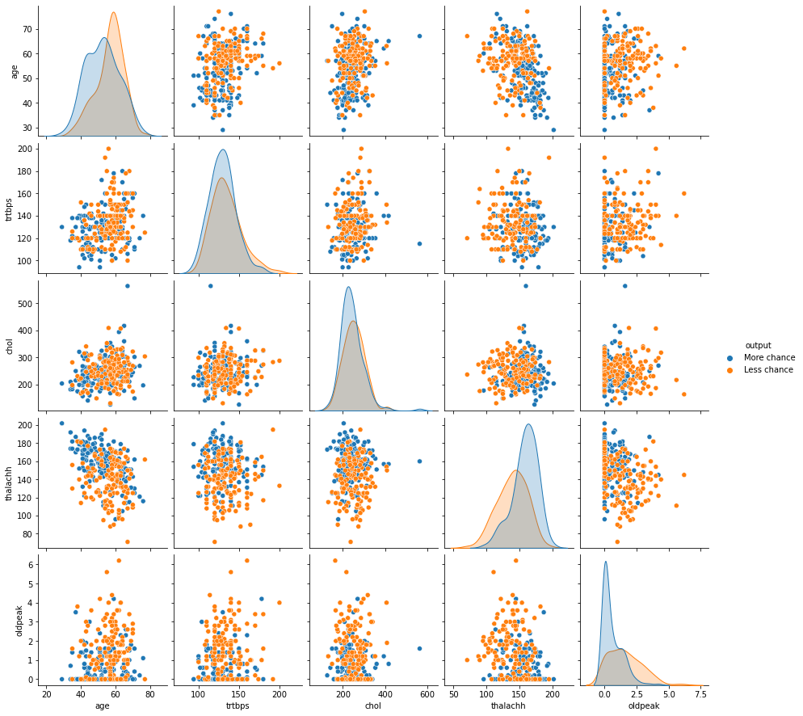

```python
g = sns.pairplot(df_replace_missing_n, hue = 'output')
plt.show()
```

As you can see here, almost all of these datas are mixed together and thus not having high correlation between each other, which is being demonstrated in the heat map. We can make similar observations here as the violin maps. The age, maximun heart rate, and the peak of ST depression are all seems to be more relative to the output of the data.

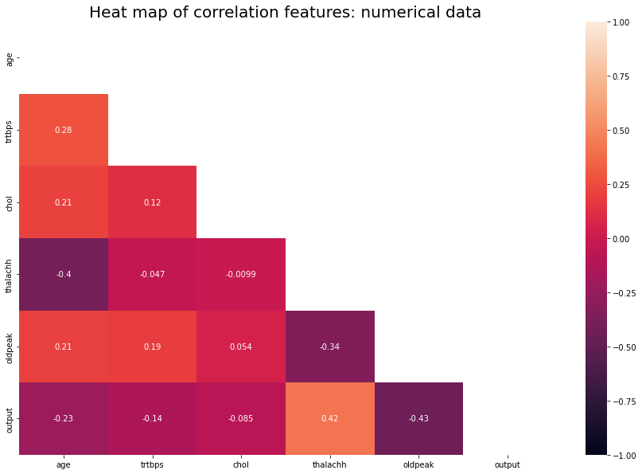

```python
#Have to reload the data in order to correctly plot the graph
df_replace_missing_n = df_replace_missing[['age', 'trtbps', 'chol', 'thalachh', 'oldpeak', 'output']].copy()
plt.figure(figsize=(15, 10))
mask = np.triu(np.ones_like(df_replace_missing_n.corr(), dtype= bool))
heatmap = sns.heatmap(df_replace_missing_n.corr(), mask=mask, vmin=-1, vmax=1, annot=True)
heatmap.set_title('Heat map of correlation features: numerical data', fontdict={'fontsize':20});
```

As you can see more clearly here, the age seems to have a relatively high positive correlation with the trtbps(resting blood pressure), and a negative correlation with the thalachh(maximun heart rate). Also, the maximun heart rate and the peak of ST depression seems to have a high correlation with the chance of the person having heart attack.

Here, I would [plot](https://seaborn.pydata.org/tutorial/regression.html) two values that could be correlated to the age of the person, and see if they have some correlation with the result. I think these two values could be highly related to the age of the person.

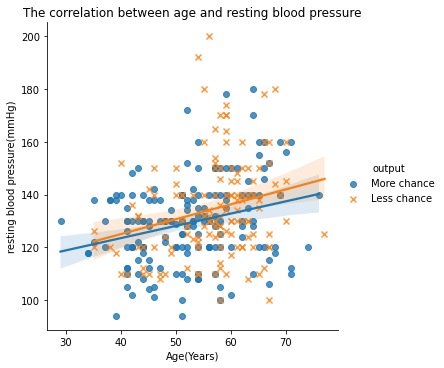

```python
#Turn the output back for easier reading
df_replace_missing_n['output'] = df_replace_missing_n['output'].map(results)
plot = sns.lmplot(x='age', y='trtbps', data=df_replace_missing_n, hue = 'output', markers=["o", "x"])
plot.set(xlabel='Age(Years)', ylabel='resting blood pressure(mmHg)', title='The correlation between age and resting blood pressure')
```

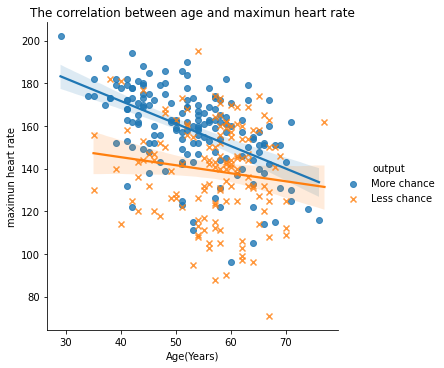

```python
plot = sns.lmplot(x='age', y='thalachh', data=df_replace_missing_n, hue = 'output', markers=["o", "x"])
plot.set(xlabel='Age(Years)', ylabel='maximun heart rate', title='The correlation between age and maximun heart rate')
```

With this graph, we can clearly see that with the progression of age, the maximun heart rate decreases, and the people that have less chance of a heart attack are generally having lower heart rate compared to the people that have more chance of heart attack.

## Data Exploration Part 2: making predictions

After seeing statisical analysis of the data, it would be time for us to try to train a few models to see it's prediction capabilities. The first thing we might want to use would be the [Lazy Predict](https://towardsdatascience.com/lazy-predict-fit-and-evaluate-all-the-models-from-scikit-learn-with-a-single-line-of-code-7fe510c7281), which basically runs the information through a lot of possible classification algorithms and give us their results. Then, we can pick the best of them and try to do the classification(to get more data) ourselves.

```python
Features = df_replace_missing.iloc[:, 0:13].values #Features
classes = df_replace_missing.iloc[:, 13].values #Results
#seperate the training and testing data
Features_train, Features_test, classes_train, classes_test = train_test_split(Features, classes, test_size=0.2, random_state=5)
```

```python
#load them into the model
lazy_clf = LazyClassifier(predictions=True)
models, predictions = lazy_clf.fit(Features_train, Features_test, classes_train, classes_test)
print(models)
```

```
                               Accuracy  Balanced Accuracy  ROC AUC  F1 Score  \
Model
ExtraTreesClassifier               0.90               0.90     0.90      0.90
RidgeClassifier                    0.90               0.90     0.90      0.90
RandomForestClassifier             0.90               0.90     0.90      0.90
RidgeClassifierCV                  0.90               0.90     0.90      0.90
QuadraticDiscriminantAnalysis      0.89               0.89     0.89      0.89
LinearSVC                          0.89               0.88     0.88      0.89
LogisticRegression                 0.89               0.88     0.88      0.89
LinearDiscriminantAnalysis         0.89               0.88     0.88      0.89
GaussianNB                         0.89               0.88     0.88      0.89
CalibratedClassifierCV             0.89               0.88     0.88      0.89
SVC                                0.89               0.88     0.88      0.88
NuSVC                              0.89               0.88     0.88      0.88
KNeighborsClassifier               0.87               0.87     0.87      0.87
XGBClassifier                      0.87               0.87     0.87      0.87
BernoulliNB                        0.87               0.87     0.87      0.87
Perceptron                         0.87               0.87     0.87      0.87
NearestCentroid                    0.87               0.87     0.87      0.87
AdaBoostClassifier                 0.85               0.85     0.85      0.85
ExtraTreeClassifier                0.85               0.85     0.85      0.85
SGDClassifier                      0.84               0.84     0.84      0.83
PassiveAggressiveClassifier        0.84               0.84     0.84      0.84
LGBMClassifier                     0.82               0.82     0.82      0.82
BaggingClassifier                  0.82               0.82     0.82      0.82
DecisionTreeClassifier             0.80               0.80     0.80      0.80
LabelSpreading                     0.75               0.75     0.75      0.75
LabelPropagation                   0.75               0.75     0.75      0.75
DummyClassifier                    0.51               0.50     0.50      0.34

                               Time Taken
Model
ExtraTreesClassifier                 0.09
RidgeClassifier                      0.01
RandomForestClassifier               0.16
RidgeClassifierCV                    0.01
QuadraticDiscriminantAnalysis        0.01
LinearSVC                            0.02
LogisticRegression                   0.01
LinearDiscriminantAnalysis           0.01
GaussianNB                           0.02
CalibratedClassifierCV               0.04
SVC                                  0.01
NuSVC                                0.01
KNeighborsClassifier                 0.01
XGBClassifier                        0.07
BernoulliNB                          0.01
Perceptron                           0.01
NearestCentroid                      0.01
AdaBoostClassifier                   0.07
ExtraTreeClassifier                  0.01
SGDClassifier                        0.01
PassiveAggressiveClassifier          0.02
LGBMClassifier                       0.05
BaggingClassifier                    0.03
DecisionTreeClassifier               0.00
LabelSpreading                       0.01
LabelPropagation                     0.00
DummyClassifier                      0.01
```

And here we have it! It seems like that a lot of algorithms are having a fairly high accuercy score, which would be a bit hard for me to make a decision on which one is "the one". Maybe do another split(with a different random state) and see what would happen?

```python
#Note that the random state has been changed here
Features_train, Features_test, classes_train, classes_test = train_test_split(Features, classes, test_size=0.2, random_state=562)
lazy_clf = LazyClassifier(predictions=True)
models, predictions = lazy_clf.fit(Features_train, Features_test, classes_train, classes_test)
print(models)
```

```
                               Accuracy  Balanced Accuracy  ROC AUC  F1 Score  \
Model
LinearSVC                          0.89               0.88     0.88      0.89
CalibratedClassifierCV             0.89               0.88     0.88      0.89
LogisticRegression                 0.89               0.88     0.88      0.89
RidgeClassifierCV                  0.89               0.88     0.88      0.88
RidgeClassifier                    0.89               0.88     0.88      0.88
LinearDiscriminantAnalysis         0.89               0.88     0.88      0.88
GaussianNB                         0.87               0.87     0.87      0.87
QuadraticDiscriminantAnalysis      0.85               0.86     0.86      0.85
SVC                                0.85               0.85     0.85      0.85
XGBClassifier                      0.84               0.84     0.84      0.84
KNeighborsClassifier               0.84               0.84     0.84      0.84
NuSVC                              0.84               0.84     0.84      0.84
PassiveAggressiveClassifier        0.84               0.83     0.83      0.84
RandomForestClassifier             0.82               0.82     0.82      0.82
NearestCentroid                    0.80               0.81     0.81      0.80
LGBMClassifier                     0.80               0.81     0.81      0.80
BernoulliNB                        0.80               0.81     0.81      0.80
DecisionTreeClassifier             0.77               0.78     0.78      0.77
ExtraTreesClassifier               0.77               0.77     0.77      0.77
SGDClassifier                      0.75               0.76     0.76      0.75
AdaBoostClassifier                 0.75               0.76     0.76      0.75
BaggingClassifier                  0.74               0.75     0.75      0.73
ExtraTreeClassifier                0.70               0.71     0.71      0.71
Perceptron                         0.69               0.69     0.69      0.69
LabelSpreading                     0.67               0.67     0.67      0.67
LabelPropagation                   0.67               0.67     0.67      0.67
DummyClassifier                    0.54               0.50     0.50      0.38

                               Time Taken
Model
LinearSVC                            0.01
CalibratedClassifierCV               0.04
LogisticRegression                   0.02
RidgeClassifierCV                    0.01
RidgeClassifier                      0.00
LinearDiscriminantAnalysis           0.01
GaussianNB                           0.02
QuadraticDiscriminantAnalysis        0.01
SVC                                  0.01
XGBClassifier                        0.06
KNeighborsClassifier                 0.01
NuSVC                                0.02
PassiveAggressiveClassifier          0.02
RandomForestClassifier               0.16
NearestCentroid                      0.01
LGBMClassifier                       0.05
BernoulliNB                          0.02
DecisionTreeClassifier               0.01
ExtraTreesClassifier                 0.09
SGDClassifier                        0.02
AdaBoostClassifier                   0.11
BaggingClassifier                    0.02
ExtraTreeClassifier                  0.01
Perceptron                           0.01
LabelSpreading                       0.01
LabelPropagation                     0.00
DummyClassifier                      0.00
```

This time, the scores are relatively lower. However, the most of them have a greater than 80 Accuercy score. We would like to choose *Random forest*, *K Neighbors Classifier(k nearest neighbors)* and *LinearSVC* for classification since they all perform well on both random selections.

### [Random Forest](https://www.datacamp.com/tutorial/random-forests-classifier-python#rdl)

Random Forest is basically decision trees, but a lot of them. Each feature can vote on whether they would be used in the classification. Using Random forest can reduce the chance of overfitting, since there are so many features we have here(we have 13 features).

```python
randf_clf = RandomForestClassifier()#build the classifier
randf_models = randf_clf.fit(Features_train, classes_train)#fit the model
randf_predict = randf_clf.predict(Features_test)#get the prediction
randf_cm = confusion_matrix(classes_test, randf_predict)#Building the confusion matrix
print(randf_cm)
```

```
[[25  3]
 [10 23]]
```

Great, we have a model and a [confusion matrix](https://en.wikipedia.org/wiki/Confusion_matrix). However, it is hard to understand what is going on here with just a confusion matrix, so let's look at some scores. We would use the feature of precision_recall_fscore_support, and you can read more about it in the link. It basically caculates out the [precision, recall](https://en.wikipedia.org/wiki/Precision_and_recall) and [f-beta score](https://machinelearningmastery.com/fbeta-measure-for-machine-learning/) for us, as the name suggested.

```python
#have to use a placeholder to hold the none value
randf_p, randf_r, radf_fbeta, placeholder = precision_recall_fscore_support(classes_test, randf_predict, average='weighted')
print('The precision of the random forest is:', randf_p,
      '\nThe recall of the random forest is:', randf_r,
      '\nThe f-beta score of the random forest is:', radf_fbeta)
```

```
The precision of the random forest is: 0.8064312736443884
The recall of the random forest is: 0.7868852459016393
The f-beta score of the random forest is: 0.7860825537958076
```

We can now say that the score of this model, the random forest, is about 80%. This is a fine-ish score, since it's better than randomly guessing. Now, we can try to look at some of the possible features that the random forest think is [important](https://scikit-learn.org/stable/auto_examples/ensemble/plot_forest_importances.html).

[output not shown]

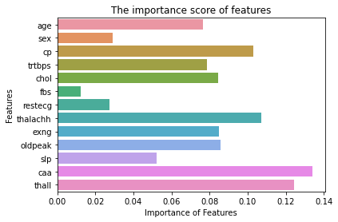

```python
importances = randf_clf.feature_importances_ #get the features that the random forest think is important
randf_feature_imp = pd.Series(randf_clf.feature_importances_, index = (df.columns)[0:13]) #put it into series
plot = sns.barplot(randf_feature_imp, y=randf_feature_imp.index) #plot the graph
plot.set(xlabel='Importance of Features', ylabel='Features', title='The importance score of features')
```

### [K Nearest Neighbors](https://www.datacamp.com/tutorial/k-nearest-neighbor-classification-scikit-learn)

K nearest Neighbors have the advantage of being able to effectively putting the data into the desired categotery quickly. However, It might be having some trouble dealing with too much features(hard for it to find the actual closest neighbor). Here, we have 13 features, it might be much and could lead to unexpected results. Actually, I would expect a bit worse results.

```python
knn_clf = KNeighborsClassifier()
knn_models = knn_clf.fit(Features_train, classes_train)#fit the model
knn_predict = knn_clf.predict(Features_test)#get the prediction
knn_cm = confusion_matrix(classes_test, knn_predict)#Building the confusion matrix
print(knn_cm)
```

```
[[18 10]
 [11 22]]
```

Just from the confusion matrix itself, it seems like the KNN is not performing so well. Let's see its scores.

```python
knn_p, knn_r, knn_fbeta, placeholder = precision_recall_fscore_support(classes_test, knn_predict, average='weighted')
print('The precision of the KNN is:', knn_p,
      '\nThe recall of the KNN is:', knn_r,
      '\nThe f-beta score of the KNN is:', knn_fbeta)
```

```
The precision of the KNN is: 0.6568329564725834
The recall of the KNN is: 0.6557377049180327
The f-beta score of the KNN is: 0.6561093781111038
```

From the result we see here, we can say that the KNN is not performing so well with its default parameters, as it's overall score is around 65%. However, we could try to find some way to make the classification more effective by [tuning the hyperparameter](https://www.kaggle.com/code/arunimsamudra/k-nn-with-hyperparameter-tuning) using grid search.

```python
grid_params = { 'n_neighbors' : [1, 3, 5, 7, 9, 11, 13, 15, 17, 19, 21, 23, 25]} #first, give it some parameter to search.
gs_clf = GridSearchCV(KNeighborsClassifier(), grid_params)
gs_model = gs_clf.fit(Features_train, classes_train)#building the model
best_grid = gs_clf.best_estimator_#extract the best result
gs_clf.best_params_ #This should give us the best n_neighbors in our search
best_grid_predict = best_grid.predict(Features_test)
best_grid_cm = confusion_matrix(classes_test, best_grid_predict)#Building the confusion matrix
print(best_grid_cm)
```

```
[[17 11]
 [ 9 24]]
```

This seems like a bit of improvement on the confusion matrix; at least it get one more right. Let's see its scores.

```python
best_grid_p, best_grid_r, best_grid_fbeta, placeholder = precision_recall_fscore_support(classes_test, best_grid_predict, average='weighted')
print('The precision of the KNN(with grid search) is:', best_grid_p,
      '\nThe recall of the KNN(with grid search) is:', best_grid_r,
      '\nThe f-beta score of the KNN(with grid search) is:', best_grid_fbeta)
```

```
The precision of the KNN(with grid search) is: 0.671086290758422
The recall of the KNN(with grid search) is: 0.6721311475409836
The f-beta score of the KNN(with grid search) is: 0.670881102896532
```

This is definintly an improvement, a 2% improvement compared to without the hyper parameter tuning! Well, I guess KNN doesn't perform too well on this dataset where there are too much features.

### [LinearSVC](https://scikit-learn.org/stable/modules/generated/sklearn.svm.LinearSVC.html)

I have read the official document, and it seems to be a linear classification algorithm which "has more flexibility in the choice of penalties and loss functions and should scale better to large numbers of samples". Maybe this would work well because it has a high score on both the random tests.

```python
LSVC_clf = LinearSVC()
LSVC_models = LSVC_clf.fit(Features_train, classes_train)#fit the model
LSVC_predict = LSVC_clf.predict(Features_test)#get the prediction
LSVC_cm = confusion_matrix(classes_test, LSVC_predict)#Building the confusion matrix
print(LSVC_cm)
```

```
[[15 13]
 [ 0 33]]
```

This confusion matrix looks very promising! Now, let's check its scores.

```python
LSVC_p, LSVC_r, LSVC_fbeta, placeholder = precision_recall_fscore_support(classes_test, LSVC_predict, average='weighted')
print('The precision of the LinearSVC is:', LSVC_p,
      '\nThe recall of the LinearSVC is:', LSVC_r,
      '\nThe f-beta score of the LinearSVC is:', LSVC_fbeta)
```

```
The precision of the LinearSVC is: 0.8471133285816108
The recall of the LinearSVC is: 0.7868852459016393
The f-beta score of the LinearSVC is: 0.7722049831818817
```